# kc_houseprice_analysis

```python
import numpy as np
import pandas as pd
import datetime
import warnings

import matplotlib.pyplot as plt
# for manual legend
import matplotlib.patches as mpatches
import seaborn as sns
import geopandas as gpd
from shapely.geometry import Point

# Regression models
from sklearn import linear_model
from sklearn.linear_model import LinearRegression
from sklearn.svm import SVR
from sklearn import tree
from sklearn.neural_network import MLPRegressor
from sklearn.neighbors import KNeighborsRegressor
from sklearn.ensemble import RandomForestRegressor
from sklearn.cluster import KMeans
from sklearn.metrics import calinski_harabasz_score, silhouette_score


from sklearn.model_selection import cross_validate
from sklearn.model_selection import train_test_split
from sklearn.preprocessing import normalize
from sklearn.preprocessing import StandardScaler

%matplotlib inline
```

### Read dataset & Exploration

```python
data = pd.read_csv(r"kc_house_data.csv", index_col = 0)
# check columns
data.head(2)
```

| id | date | price | bedrooms | bathrooms | sqft_living | sqft_lot | floors | waterfront | view | condition | grade | sqft_above | sqft_basement | yr_built | yr_renovated | zipcode | lat | long | sqft_living15 | sqft_lot15 |
| --- | --- | --- | --- | --- | --- | --- | --- | --- | --- | --- | --- | --- | --- | --- | --- | --- | --- | --- | --- | --- |
| 7129300520 | 20141013T000000 | 221900.0 | 3 | 1.00 | 1180 | 5650 | 1.0 | 0 | 0 | 3 | 7 | 1180 | 0 | 1955 | 0 | 98178 | 47.5112 | -122.257 | 1340 | 5650 |
| 6414100192 | 20141209T000000 | 538000.0 | 3 | 2.25 | 2570 | 7242 | 2.0 | 0 | 0 | 3 | 7 | 2170 | 400 | 1951 | 1991 | 98125 | 47.7210 | -122.319 | 1690 | 7639 |

```python
print("House sales", format(data.shape[0], ',d'))
print("Out of which, %s are renovated houses" %data["yr_renovated"][data["yr_renovated"] != 0].shape[0])
```

```
House sales 21,613
Out of which, 914 are renovated houses
```

```python
# Check column dtypes
data.dtypes
# All dtypes are numeric except the date column which is the object
# We will clean the date to make it in more presentable format
```

```
date              object
price            float64
bedrooms           int64
bathrooms        float64
sqft_living        int64
sqft_lot           int64
floors           float64
waterfront         int64
view               int64
condition          int64
grade              int64
sqft_above         int64
sqft_basement      int64
yr_built           int64
yr_renovated       int64
zipcode            int64
lat              float64
long             float64
sqft_living15      int64
sqft_lot15         int64
dtype: object
```

```python
# Check for missing values
data.isnull().sum()
```

```
date             0
price            0
bedrooms         0
bathrooms        0
sqft_living      0
sqft_lot         0
floors           0
waterfront       0
view             0
condition        0
grade            0
sqft_above       0
sqft_basement    0
yr_built         0
yr_renovated     0
zipcode          0
lat              0
long             0
sqft_living15    0
sqft_lot15       0
dtype: int64
```

# Feature Creation

```python
# Avg price per sqft_living
data["price_per_sqft"] = round(data["price"]/data["sqft_living"], 0)

# Bedroom to bathroom ratio
data["bed_bath"] = round(data["bathrooms"]/data["bedrooms"], 1)
data.fillna(0, inplace = True)
data["bed_bath"] = data["bed_bath"].replace([np.inf, -np.inf], 0)

# Datetime
# From date column create three columns: year, month and day
data["year"] = data["date"].apply(lambda x: x[:4])
data["month"] = data["date"].apply(lambda x: x[4:6])
data["day"] = data["date"].apply(lambda x: x[6:8])
data.drop(["date"], axis = 1, inplace = True)
data["datetime"] = pd.to_datetime(data[["year", "month",  "day"]])


# Years since last renovation
# Years since built - the age of the house
now = datetime.datetime.now()
data["age"] = data["yr_built"].apply(lambda x: (now.year - x))

# Function for apply
def years_since_renovation(row):
    if row["yr_renovated"] == 0:
        return row["age"]
    else:
        return (now.year - row["yr_renovated"])
# Extract the years since renovation
data["yr_renovated"] = data.apply(lambda row: years_since_renovation(row), axis = 1)
```

# Exploratory Data Analysis

### Scatterplot

```python
# How does the lot area impact the price
print("Smallest lot area is", data["sqft_lot"].min())
print("Largest lot area is", format(data["sqft_lot"].max(), ",d"))
```

```
Smallest lot area is 520
Largest lot area is 1,651,359
```

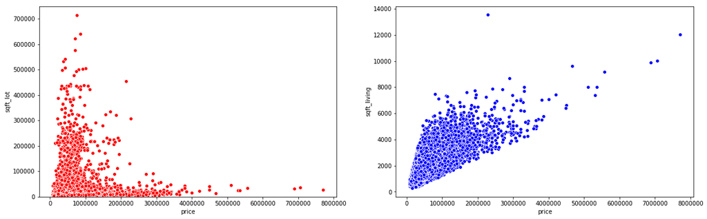

```python
# The lot size is not a good indicator of the house price
# It is likely that the bigger the lot the futher away the property is from the centre, or expesive areas
# Therefore, the bigger lot does not necesseraly mean a more expensive property

fig, ax = plt.subplots(nrows = 1, ncols = 2, figsize = (20, 6))
sns.scatterplot(data["price"], data["sqft_lot"], color = "red", ax = ax[0])
ax[0].set_ylim([0, 750000])
sns.scatterplot(data["price"], data["sqft_living"], color = "blue", ax = ax[1])
plt.show()
```

### Comments

The lot size is likely to be useful feature, because the bigger lot sizes are most often found outside the expensive zipcodes, therefore implies a cheaper price per sqft

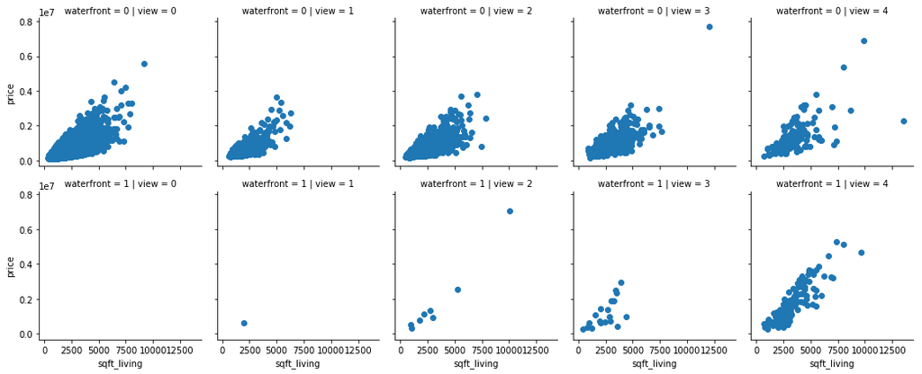

```python
g = sns.FacetGrid(data, col="view",  row="waterfront")
g.map(plt.scatter, "sqft_living", "price")
plt.show()
```

### Comments

1) The properties on waterfront have a stepper increase in price for each increase in sqft_living, compared to properties with no waterfront  
2) There are a few exceptionally high prices for properties with the view level 4 or 3

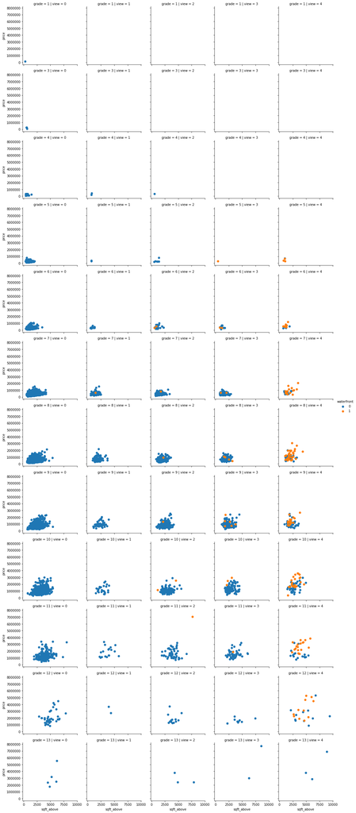

```python
g = sns.FacetGrid(data, col="view", row = "grade", hue="waterfront")
g.map(plt.scatter, "sqft_above", "price").add_legend()
plt.show()
```

### Comments

1) The properties prices increase with the grade of the property  
2) Properties on waterfront are most often having a view rating 3 or higher  
3) The properties sqft_above prices increase with the grade of the property

### Correlation Analysis

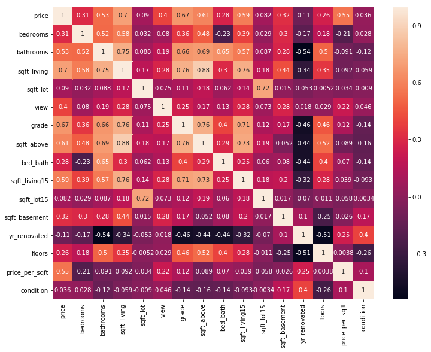

```python
plt.figure(figsize = (12, 9))
sns.heatmap(data[["price", "bedrooms", \
                  "bathrooms", "sqft_living", "sqft_lot", "view", "grade", "sqft_above", "bed_bath", "sqft_living15", "sqft_lot15", "sqft_basement", \
                  "yr_renovated", "floors", "price_per_sqft", "condition"]].corr(), annot=True)
plt.show()
```

### Comments

1) Top 3 correlated features with price:

```
 - sqft_living (0.7)
 - grade (0.67)
 - sqft_above (0.61)
```

these features are highly correlated among themselves, which means after adding one of them to the model,  
adding the subsequent features may bring limited impact onto the accuracy of the model  
2) sqft_living15 less correlated than sqft_living, therefore use sqft_living  
3) sqft_lot not highly correlated with price (as expected)  
4) Slight negative correlation between price and year since last renovation (as expected)  
5) Other useful features:

```
- bathrooms (0.53)
- which is higher than bedrooms (0.31)
- view (0.4)
```

**Price per sqft**  
There is a small positive correlation between price per sqft and:

```
 - view (0.22)
 - years since last renovation (0.25)
```

### Map visualization - shp file

```python
# We found the shapefile of King County geography regions by zip code which will help us plot the dataset onto the map
zip_codes = gpd.read_file(r"SHP_files\Zip_Codes.shp")
zip_codes.head(2)
```

|  | OBJECTID | ZIP | ZIPCODE | COUNTY | SHAPE_Leng | SHAPE_Area | geometry |
| --- | --- | --- | --- | --- | --- | --- | --- |
| 0 | 1 | 98001 | 98001 | 033 | 146572.386131 | 5.266293e+08 | POLYGON ((1279215.20967415 133057.4998951554, ... |
| 1 | 2 | 98002 | 98002 | 033 | 102448.485811 | 2.055688e+08 | POLYGON ((1294421.720280305 132177.9002783298,... |

```python
# Combine dataset with zip_codes to get the geometry values for each zipcode
data_merged = pd.merge(data, zip_codes[["ZIP", "geometry"]], left_on = "zipcode", right_on = "ZIP")

# We extract the average price per sqft, average lot size, total number of sales per zipcode from the dataset
# To create a new geodataframe
# http://geopandas.org/reference/geopandas.GeoDataFrame.html
#

gdf = data_merged.groupby("zipcode").agg({"price_per_sqft": np.mean, \
                                          "sqft_lot": np.mean, "price": 'count', "geometry": 'first'}).rename(columns = {"price": "count"})
gdf = gpd.GeoDataFrame(gdf, geometry="geometry")

gdf.head(2)
```

| zipcode | price_per_sqft | sqft_lot | count | geometry |
| --- | --- | --- | --- | --- |
| 98001 | 151.408840 | 14937.450276 | 362 | POLYGON ((1279215.20967415 133057.4998951554, ... |
| 98002 | 151.160804 | 7517.633166 | 199 | POLYGON ((1294421.720280305 132177.9002783298,... |

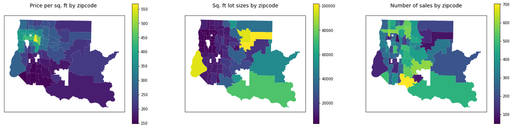

```python
fig, ax = plt.subplots(nrows = 1, ncols = 3, figsize = (25, 6))

gdf.plot(ax = ax[0], cmap = "viridis", column = "price_per_sqft", legend = True)
ax[0].set_xticks([])
ax[0].set_yticks([])
ax[0].set_title("Price per sq. ft by zipcode \n", fontsize = 14)


gdf.plot(ax = ax[1], cmap = "viridis", column = "sqft_lot", legend = True)
ax[1].set_xticks([])
ax[1].set_yticks([])
ax[1].set_title("Sq. ft lot sizes by zipcode\n", fontsize = 14)


gdf.plot(ax = ax[2], cmap = "viridis", column = "count", legend = True)
ax[2].set_xticks([])
ax[2].set_yticks([])
ax[2].set_title("Number of sales by zipcode\n", fontsize = 14)

plt.show()
```

### TimeSeries analysis

```python
zip_fips = pd.read_csv(r"SHP_files\ZIP-COUNTY-FIPS_2017-06.csv")
zip_fips.head(2)
```

|  | ZIP | COUNTYNAME | STATE | STCOUNTYFP | CLASSFP |
| --- | --- | --- | --- | --- | --- |
| 0 | 36003 | Autauga County | AL | 1001 | H1 |
| 1 | 36006 | Autauga County | AL | 1001 | H1 |

```python
data_merged2 = pd.merge(data_merged, zip_fips[["ZIP", "STCOUNTYFP"]], left_on = "zipcode", right_on = "ZIP")
```

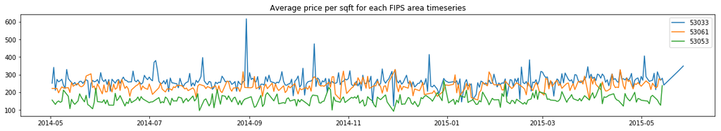

```python
warnings.filterwarnings("ignore")
plt.figure(figsize = (20, 3))
for i in data_merged2["STCOUNTYFP"].unique():
    plt.plot(data_merged2[data_merged2["STCOUNTYFP"] == i].groupby(by = "datetime").mean()["price_per_sqft"], label = i)
plt.legend()
plt.title("Average price per sqft for each FIPS area timeseries")
plt.show()
```

### Comments

1) Average price per sqft depends on the area of the property  
2) There is no visible upward or downward trend for any areas  
3) However there are a few spikes, most likely driven by sales of more luxurious, expensive properties

### Price variance by zipcode

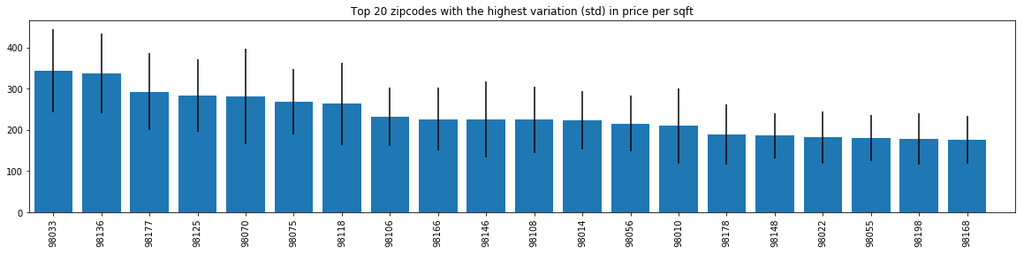

```python
price_by_zip = data.groupby("zipcode").agg({"price_per_sqft": \
                                            [np.mean, np.std, ]}).sort_values(by = ("price_per_sqft", "std"),\
                                                                            ascending = False)[:20].sort_values(by = \
                                                                                                                ("price_per_sqft","mean"), ascending = False)
var_per_per_zip = price_by_zip.iloc[:, 1] / price_by_zip.iloc[:, 0]
mean_std_zipcode = data.groupby("zipcode").agg({"price_per_sqft": [np.mean, np.std]})
mean_std_zipcode["perc_var"] = mean_std_zipcode[("price_per_sqft", "std")] / mean_std_zipcode[("price_per_sqft", "mean")]
price_by_zip = mean_std_zipcode.sort_values(by = ("perc_var"), ascending = False)[:20].sort_values(by = ("price_per_sqft","mean"), ascending = False)
indices = [str(x) for x in price_by_zip.index]

plt.figure(figsize = (20, 4))
plt.bar(np.arange(len(indices)), price_by_zip.iloc[:, 0], yerr = price_by_zip.iloc[:, 1])
plt.xticks(np.arange(len(indices)), indices, rotation = 90)
plt.xlim([-0.5, len(indices)])
plt.title("Top 20 zipcodes with the highest variation (std) in price per sqft")
plt.show()
```

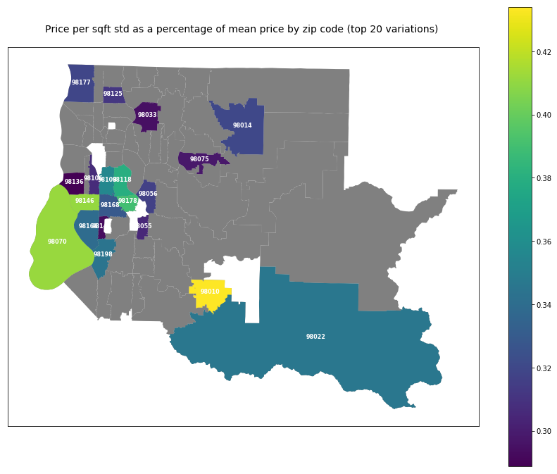

```python
gdf2 = gdf[gdf.index.isin(price_by_zip.index)]
gdf2["std"] = [price_by_zip.loc[int(x)][2] for x in gdf2.index]

base = gdf.plot(figsize = (15, 12), color = "grey", legend = True)
ax = gdf2.plot(ax = base, cmap = "viridis", column = "std", legend = True)
plt.xticks([])
plt.yticks([])
gdf2[gdf2.index.isin(price_by_zip.index)].apply(lambda x: ax.annotate(s=x["zip"], xy=x.geometry.centroid.coords[0], ha='center', color = "white", fontsize = 8, fontweight = "bold"), axis=1)
plt.title("Price per sqft std as a percentage of mean price by zip code (top 20 variations) \n", fontsize = 14)
plt.show()
```

### Comments

Some zipcodes have a higher variation in the price per sqft, which means it has a large difference of type of properties there are  
For example,

- 98010 zipcode property prices vary by 42% from average price in the area

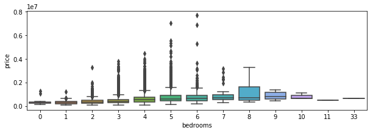

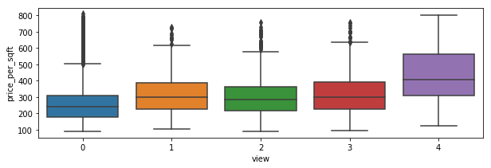

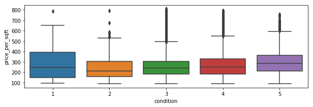

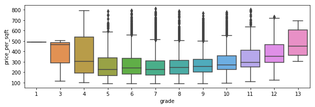

```python
plt.figure(figsize = (10, 3))
sns.boxplot(data = data, x = "bedrooms", y = "price")
plt.show()

plt.figure(figsize = (10, 3))
sns.boxplot(data = data, x = "view", y = "price_per_sqft")
plt.show()


plt.figure(figsize = (10, 3))
sns.boxplot(data = data, x = "condition", y = "price_per_sqft")
plt.show()

plt.figure(figsize = (10, 3))
sns.boxplot(data = data, x = "grade", y = "price_per_sqft")
plt.show()
```

### Comments

1) There is no strong relationship between property price and number of bedrooms, especially past 6 bedroom properties,  
which means there are other features impacting the price, such as view or condition

2) Although average price per sqft tend to increase with the quality of view, there are a lot of outliers with high price properties with view level 0

### Identify areas with similar types of properties (Clustering)

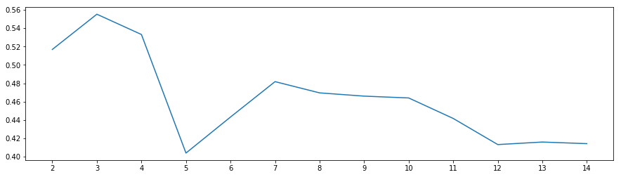

```python
# data reshape
zipcode_df = data.groupby("zipcode").agg({"price_per_sqft": np.mean,\
                                          "sqft_lot": np.mean, "waterfront": np.sum})
zipcode_df_norm = normalize(zipcode_df, axis = 0)

# Find the best number of clusters
scores = []
for i in range(2, 15):
    km = KMeans(n_clusters=i)
    km.fit(zipcode_df_norm)
    zipcode_df["group"] = km.labels_
    sil_score = silhouette_score(zipcode_df_norm, km.labels_, metric = "euclidean")
    scores.append(sil_score)
plt.figure(figsize = (15, 4))
plt.plot(np.arange(2, 15), scores)
plt.xticks(np.arange(2, 15))
plt.show()
# if we use 3 clusters, it gives the highest Silhouette score
```

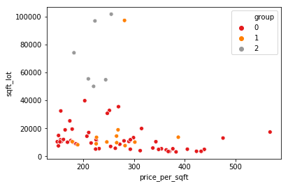

```python
# Cluster zipcodes into 3 groups
km = KMeans(n_clusters=3)
km.fit(zipcode_df_norm)
zipcode_df["group"] = km.labels_

sns.scatterplot(data = zipcode_df, x = "price_per_sqft", y = "sqft_lot", hue = "group", palette = "Set1")
plt.show()
```

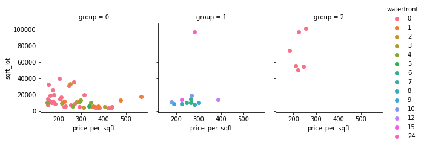

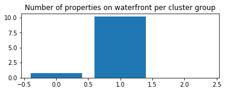

```python
g = sns.FacetGrid(zipcode_df, col="group", hue="waterfront")
g.map(plt.scatter, "price_per_sqft", "sqft_lot").add_legend()
plt.show()

plt.figure(figsize = (6, 2))
plt.bar(np.arange(3), zipcode_df.groupby("group").mean()["waterfront"].values)
plt.title("Number of properties on waterfront per cluster group")
plt.show()
```

### Comments

Group 1 has the highest number of propeties located on waterfront

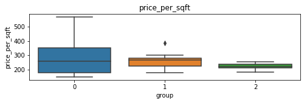

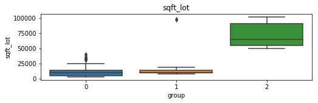

```python
# Explore clusters
cols = ["price_per_sqft", "sqft_lot"]
for i in cols:
    plt.figure(figsize = (8, 2))
    sns.boxplot(data = zipcode_df, x = "group", y = i)
    plt.title(i)
    plt.show()
```

### Comments

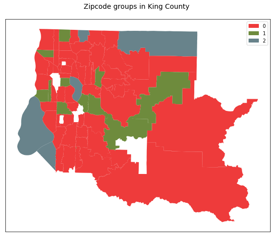

```python
gdf["group"] = [zipcode_df.loc[x]["group"] for x in gdf.index]

colormap = {"0": "#EE3B3B", "1": "#6E8B3D", "2": "#68838B"}
gdf.plot(figsize = (10, 8), color = [colormap[str(int(x))] for x in gdf["group"]], column = "group", legend = True)
plt.xticks([])
plt.yticks([])
plt.title("Zipcode groups in King County \n", fontsize = 14)
patch0 = mpatches.Patch(color="#EE3B3B", label="0")
patch1 = mpatches.Patch(color="#6E8B3D", label="1")
patch2 = mpatches.Patch(color="#68838B", label="2")
plt.legend(handles=[patch0, patch1, patch2])
plt.show()
```

### Comments

1) Group 2 (blue) - properties with a large lot sizes  
2) Group 1 (green) - properties with waterfront and low price per sqft variance  
3) Group 0 (red) - low lot size properties, only a few waterfront properties with high variation in price per sqft

### Duplicate House sales

```python
duplicate_indices = np.unique(data.index, return_counts=True)[0][np.unique(data.index, return_counts=True)[1]>1]
duplicate_counts = np.unique(data.index, return_counts=True)[1][np.unique(data.index, return_counts=True)[1]>1]
duplicate_data = data[data.index.isin(duplicate_indices)]
print("Number of houses sold multiple times ", len(set(duplicate_indices)))
```

```
Number of houses sold multiple times  176
```

For duplicate house sales, during modeling we will keep only the latest sale

## Modelling

```python
def Regression_models_analysis(MLA, X, y):
    warnings.filterwarnings("ignore")
    #create table to compare MLA metrics
    MLA_columns = ['MLA Name', 'MLA Parameters','MLA Test MSQE', 'MLA Test R2', 'MLA Test MAX error', 'MLA Time']
    MLA_compare = pd.DataFrame(columns = MLA_columns)

    #create table to compare MLA predictions
    X_train, X_test, y_train, y_test = train_test_split(X, y, test_size = 0.2, random_state = 0)
    MLA_predict = pd.DataFrame(y_test)

    #index through MLA and save performance to table
    row_index = 0
    for alg in MLA:
        #set name and parameters
        MLA_name = alg.__class__.__name__
        MLA_compare.loc[row_index, 'MLA Name'] = MLA_name
        MLA_compare.loc[row_index, 'MLA Parameters'] = str(alg.get_params())

        #score model with cross validation: http://scikit-learn.org/stable/modules/generated/sklearn.model_selection.cross_validate.html#sklearn.model_selection.cross_validate
        scores = cross_validate(alg, X, y, cv = 5, scoring = ("neg_mean_squared_error", "r2", "max_error"))

        MLA_compare.loc[row_index, 'MLA Time'] = scores["fit_time"].mean()
        MLA_compare.loc[row_index, 'MLA Test MSQE'] = format(int(scores["test_neg_mean_squared_error"].mean()), ",d")
        MLA_compare.loc[row_index, 'MLA Test R2'] = scores["test_r2"].mean()
        MLA_compare.loc[row_index, 'MLA Test MAX error'] =   format(int(scores["test_max_error"].max()), ",d")

        #save MLA predictions
        alg.fit(X_train, y_train)
        MLA_predict[MLA_name] = alg.predict(X_test)
        row_index += 1


    #print and sort table: https://pandas.pydata.org/pandas-docs/stable/generated/pandas.DataFrame.sort_values.html
    MLA_compare.sort_values(by = ['MLA Test R2'], ascending = False, inplace = True)
    #MLA_predict
    return MLA_compare, MLA_predict

def show_errors(m1_result, col):
    m1_analysis = m1_result[["price", col]]
    m1_analysis["diff"] = m1_analysis[col] - m1_analysis["price"]
    plt.figure(figsize = (10, 8))
    plt.scatter(m1_analysis["price"], m1_analysis["diff"], s= 10)
    plt.xlabel("Price")
    plt.ylabel("Diff = prediction - price")
    plt.xticks(np.linspace(0, 5000000, 6, dtype = np.int), [format(x, ",d") for x in np.linspace(0, 5000000, 6, dtype = np.int)])
    plt.yticks(np.linspace(-1500000, 2000000, 8, dtype = np.int), [format(x, ",d") for x in np.linspace(-1500000, 2000000, 8, dtype = np.int)])
```

```python
# pipeline
#Machine Learning Algorithm (MLA) Selection and Initialization
MLA = [
    #tree
    tree.DecisionTreeRegressor(),
    #Ensemble Methods
    RandomForestRegressor(n_estimators = 200, criterion = "mse"),
    #Linear models
    linear_model.Lasso(alpha = 0.1),
    LinearRegression(),
    #KNN
    KNeighborsRegressor(n_neighbors = 5)
    ]
```

## Feature Ranking

```python
from sklearn.feature_selection import RFE, f_regression
from sklearn.linear_model import LinearRegression, Ridge, Lasso
from sklearn.preprocessing import MinMaxScaler
from sklearn.ensemble import RandomForestRegressor
```

```python
# Define X and y for ranking
X_rank = data[['bedrooms', 'bathrooms', 'sqft_living', 'sqft_lot', 'floors', \
       'waterfront', 'view', 'condition', 'grade', 'sqft_above', \
       'sqft_basement', 'yr_built', 'yr_renovated', 'zipcode', \
       'sqft_living15', 'sqft_lot15', 'bed_bath', 'year', \
       'age']]

y_rank = data["price"]

colnames = X_rank.columns
feature_ranks = {"name" : colnames}
```

```python
lr = LinearRegression(normalize=True)
lr.fit(X_rank, y_rank)
#stop the search when only the last feature is left
rfe = RFE(lr, n_features_to_select=1, verbose =3 )
rfe.fit(X_rank, y_rank)
# feature_ranks["RFE"] = ranking(list(map(float, rfe.ranking_)), colnames, order=-1)
feature_ranks["RFE_LR"] = rfe.ranking_
```

```
Fitting estimator with 19 features.
Fitting estimator with 18 features.
Fitting estimator with 17 features.
Fitting estimator with 16 features.
Fitting estimator with 15 features.
Fitting estimator with 14 features.
Fitting estimator with 13 features.
Fitting estimator with 12 features.
Fitting estimator with 11 features.
Fitting estimator with 10 features.
Fitting estimator with 9 features.
Fitting estimator with 8 features.
Fitting estimator with 7 features.
Fitting estimator with 6 features.
Fitting estimator with 5 features.
Fitting estimator with 4 features.
Fitting estimator with 3 features.
Fitting estimator with 2 features.
```

```python
rf = RandomForestRegressor(n_estimators = 200, criterion = "mse")
rf.fit(X_rank, y_rank)
#stop the search when only the last feature is left
rfe = RFE(rf, n_features_to_select=1, verbose =3 )
rfe.fit(X_rank, y_rank)
# feature_ranks["RFE"] = ranking(list(map(float, rfe.ranking_)), colnames, order=-1)
feature_ranks["RFE_RF"] = rfe.ranking_
```

```
Fitting estimator with 19 features.
Fitting estimator with 18 features.
Fitting estimator with 17 features.
Fitting estimator with 16 features.
Fitting estimator with 15 features.
Fitting estimator with 14 features.
Fitting estimator with 13 features.
Fitting estimator with 12 features.
Fitting estimator with 11 features.
Fitting estimator with 10 features.
Fitting estimator with 9 features.
Fitting estimator with 8 features.
Fitting estimator with 7 features.
Fitting estimator with 6 features.
Fitting estimator with 5 features.
Fitting estimator with 4 features.
Fitting estimator with 3 features.
Fitting estimator with 2 features.
```

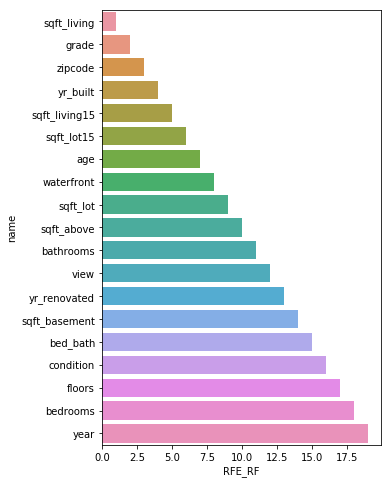

```python
feature_ranks = pd.DataFrame(feature_ranks)
feature_ranks.sort_values(by = "RFE_RF", inplace = True)

plt.figure(figsize = (5, 8))
sns.barplot( data = feature_ranks, y = "name", x = "RFE_RF" )
plt.show()
```

### Comments

Linear model (linear regression) and non linear model (random forest) show different feature importance ranking  
Since the relationship is non linear, e.g. the property price grows with the increase in sqft in non linear manner  
(may have a steeper growth for specific zipcode or grade of the building)  
We follow a result of non linear model and run our first model on the first top 3 features

### Model 1 - Top3 features

- sqft_living
- grade
- zipcode

```python
# DATA PREPARATION
# Choose the columns
sales = data[["sqft_living", "grade", "zipcode", "price", "datetime"]]

# Remove duplicates, keep only last one
sales = sales.sort_values(by = "datetime", ascending=False)
sales.drop_duplicates(subset = ["sqft_living", "grade", "zipcode"], \
                      keep='first', inplace=True)

# check duplicates
# np.unique(sales.index, return_counts=True)[0][np.unique(sales.index, return_counts=True)[1]>1]

# Convert non numeric columns to numeric -> Dummy encoder
# Zipcode -> it is non ordinary variable therefore we use pd.get_dummies to encode this variable
# Since there any many variables, the quality of regression is likely to decline from using zipcode as it is
sales = pd.merge(sales, pd.get_dummies(sales["zipcode"]), left_index = True, right_index = True).drop(["zipcode"], axis = 1)

sales.drop(["datetime"], axis = 1, inplace= True)
```

```python
y = sales["price"]
X = sales.drop("price", axis = 1)
#Normlize to make features comparable to each other
scaler = StandardScaler()
X_norm = scaler.fit_transform(X)
```

```python
m1_compare, m1_result = Regression_models_analysis(MLA, X_norm, y)
```

```python
m1_compare
```

|  | MLA Name | MLA Parameters | MLA Test MSQE | MLA Test R2 | MLA Test MAX error | MLA Time |
| --- | --- | --- | --- | --- | --- | --- |
| 4 | KNeighborsRegressor | {'algorithm': 'auto', 'leaf_size': 30, 'metric... | -38,590,733,913 | 0.765036 | -1,977,200 | 0.4274 |
| 1 | RandomForestRegressor | {'bootstrap': True, 'criterion': 'mse', 'max_d... | -41,184,889,887 | 0.748371 | -2,234,974 | 35.2247 |
| 2 | Lasso | {'alpha': 0.1, 'copy_X': True, 'fit_intercept'... | -43,545,189,875 | 0.733451 | -2,215,689 | 1.55187 |
| 3 | LinearRegression | {'copy_X': True, 'fit_intercept': True, 'n_job... | -43,547,697,260 | 0.733432 | -2,216,008 | 0.0831988 |
| 0 | DecisionTreeRegressor | {'criterion': 'mse', 'max_depth': None, 'max_f... | -61,495,696,322 | 0.626643 | -3,100,000 | 0.905599 |

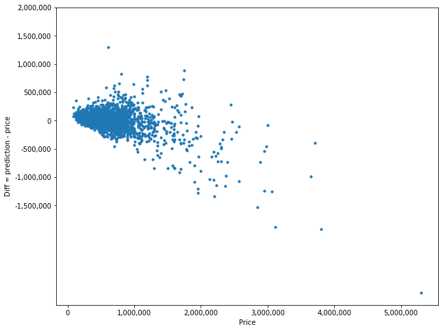

```python
show_errors(m1_result, "KNeighborsRegressor")
```

### Comments

1) The model underestimates the prices of more expensive properties

```python
# DATA PREPARATION
# Choose the columns
sales = data[["sqft_living", "grade", "zipcode", "age", "sqft_lot15", "waterfront", "sqft_above", "bathrooms", "price",  "datetime"]]

# Remove duplicates, keep only last one
sales = sales.sort_values(by = "datetime", ascending=False)
sales.drop_duplicates(subset = ["sqft_living", "grade", "zipcode", "age", "sqft_lot15", "waterfront", "sqft_above", "bathrooms"], \
                      keep='first', inplace=True)

# check duplicates
# np.unique(sales.index, return_counts=True)[0][np.unique(sales.index, return_counts=True)[1]>1]

# Convert non numeric columns to numeric -> Dummy encoder
# Zipcode -> it is non ordinary variable therefore we use pd.get_dummies to encode this variable
# Since there any many variables, the quality of regression is likely to decline from using zipcode as it is
sales = pd.merge(sales, pd.get_dummies(sales["zipcode"]), left_index = True, right_index = True).drop(["zipcode"], axis = 1)

# lot_size is the ordinary variable, therefore can encode using
# lot_size_mapping = {"small" : 0, "medium": 1, "large": 2}
# sales["lot_size_num"] = sales["lot_size"].apply(lambda x: lot_size_mapping[x])

sales.drop(["datetime"], axis = 1, inplace= True)
```

```python
y = sales["price"]
X2 = sales.drop("price", axis = 1)
#Normlize to make features comparable to each other
scaler = StandardScaler()
X2_norm = scaler.fit_transform(X2)
```

```python
m2_compare, m2_result = Regression_models_analysis(MLA, X2_norm, y)
m2_compare
```

|  | MLA Name | MLA Parameters | MLA Test MSQE | MLA Test R2 | MLA Test MAX error | MLA Time |
| --- | --- | --- | --- | --- | --- | --- |
| 1 | RandomForestRegressor | {'bootstrap': True, 'criterion': 'mse', 'max_d... | -24,543,172,704 | 0.820036 | -1,171,636 | 62.7384 |
| 4 | KNeighborsRegressor | {'algorithm': 'auto', 'leaf_size': 30, 'metric... | -24,768,412,454 | 0.818314 | -1,646,250 | 0.367981 |
| 3 | LinearRegression | {'copy_X': True, 'fit_intercept': True, 'n_job... | -28,973,838,356 | 0.786848 | -1,688,212 | 0.112801 |
| 2 | Lasso | {'alpha': 0.1, 'copy_X': True, 'fit_intercept'... | -28,984,830,274 | 0.786769 | -1,687,509 | 2.09297 |
| 0 | DecisionTreeRegressor | {'criterion': 'mse', 'max_depth': None, 'max_f... | -43,159,115,186 | 0.68217 | -1,970,000 | 0.638773 |

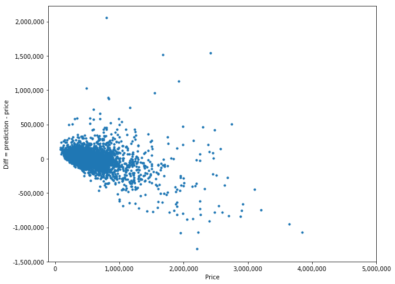

```python
show_errors(m2_result, "RandomForestRegressor")
```

### Comments

2) Maximum error is now improved from being 2m to 1.1m, R2 improvement from 0.76 to 0.82

Therefore, we chose RandomForest as being the best model based on the analysis performed

# Evaluation

```python
# Analyse neighbour model result
KNN_result = m2_result[["price", "RandomForestRegressor"]]
KNN_result["diff"] = KNN_result["RandomForestRegressor"] - KNN_result["price"]
KNN_result["diff_perc"] = round(KNN_result["diff"] / KNN_result["price"], 2)
KNN_data = pd.merge(data.drop("price", axis = 1), KNN_result, left_index = True, right_index = True, how = "right")
KNN_data["geometry"] = KNN_data.apply(lambda x: Point(x["long"], x["lat"]), axis = 1)
sale_points_gdf = gpd.GeoDataFrame(KNN_data[["zipcode", "diff", "diff_perc", "geometry"]],
                         crs={'init' :'epsg:4326'})

count_diff = KNN_data[abs(KNN_data["diff_perc"]) > 0.20].groupby("zipcode").count()["diff"].reset_index().rename(columns = {"diff" : "count_diff_0.2"})
KNN_data = pd.merge(KNN_data, count_diff, left_on = "zipcode", right_on = "zipcode", how = "left")

pred_analysis_gdf = pd.merge(gdf, KNN_data.groupby("zipcode").agg({"diff": np.mean, "diff_perc": np.mean, "count_diff_0.2": np.mean}), \
                             left_index =True, right_index = True )
pred_analysis_gdf["abs_diff"] = [abs(x) for x in pred_analysis_gdf["diff"]]
pred_analysis_gdf["abs_diff_perc"] = [abs(x) for x in pred_analysis_gdf["diff_perc"]]

zipcodes_with_highest_diff = KNN_data[abs(KNN_data["diff_perc"]) > 1].zipcode.tolist()
```

```python
KNN_data.head(2)
```

|  | bedrooms | bathrooms | sqft_living | sqft_lot | floors | waterfront | view | condition | grade | sqft_above | ... | month | day | datetime | age | price | RandomForestRegressor | diff | diff_perc | geometry | count_diff_0.2 |
| --- | --- | --- | --- | --- | --- | --- | --- | --- | --- | --- | --- | --- | --- | --- | --- | --- | --- | --- | --- | --- | --- |
| 0 | 3 | 2.25 | 1530 | 1245 | 2.0 | 0 | 0 | 3 | 9 | 1050 | ... | 06 | 05 | 2014-06-05 | 5 | 465000.0 | 626658.500 | 161658.500 | 0.35 | POINT (-122.297 47.6018) | 22 |
| 1 | 5 | 1.00 | 3020 | 4800 | 2.0 | 0 | 0 | 3 | 7 | 3020 | ... | 12 | 18 | 2014-12-18 | 118 | 630000.0 | 587649.875 | -42350.125 | -0.07 | POINT (-122.313 47.6025) | 22 |

2 rows × 31 columns

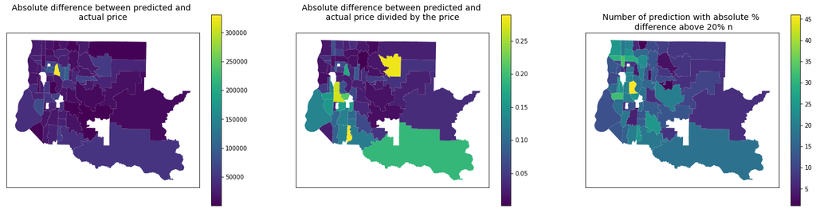

```python
fig, ax = plt.subplots(nrows = 1, ncols = 3, figsize = (25, 6))

pred_analysis_gdf.plot(ax = ax[0], cmap = "viridis", column = "abs_diff", legend = True)
ax[0].set_xticks([])
ax[0].set_yticks([])
ax[0].set_title("Absolute difference between predicted and \n actual price \n", fontsize = 14)


pred_analysis_gdf.plot(ax = ax[1], cmap = "viridis", column = "abs_diff_perc", legend = True)
ax[1].set_xticks([])
ax[1].set_yticks([])
ax[1].set_title("Absolute difference between predicted and \n actual price divided by the price \n", fontsize = 14)


pred_analysis_gdf.plot(ax = ax[2], cmap = "viridis", column = "count_diff_0.2", legend = True)
ax[2].set_xticks([])
ax[2].set_yticks([])
ax[2].set_title("Number of prediction with absolute % \n difference above 20% n", fontsize = 14)

plt.show()
```

```python
m1_compare["model"] = "m1"
m2_compare["model"] = "m2"
compare_all = pd.concat([m1_compare, m2_compare], axis = 0)
compare_all
```

|  | MLA Name | MLA Parameters | MLA Test MSQE | MLA Test R2 | MLA Test MAX error | MLA Time | model |
| --- | --- | --- | --- | --- | --- | --- | --- |
| 4 | KNeighborsRegressor | {'algorithm': 'auto', 'leaf_size': 30, 'metric... | -38,590,733,913 | 0.765036 | -1,977,200 | 0.4274 | m1 |
| 1 | RandomForestRegressor | {'bootstrap': True, 'criterion': 'mse', 'max_d... | -41,184,889,887 | 0.748371 | -2,234,974 | 35.2247 | m1 |
| 2 | Lasso | {'alpha': 0.1, 'copy_X': True, 'fit_intercept'... | -43,545,189,875 | 0.733451 | -2,215,689 | 1.55187 | m1 |
| 3 | LinearRegression | {'copy_X': True, 'fit_intercept': True, 'n_job... | -43,547,697,260 | 0.733432 | -2,216,008 | 0.0831988 | m1 |
| 0 | DecisionTreeRegressor | {'criterion': 'mse', 'max_depth': None, 'max_f... | -61,495,696,322 | 0.626643 | -3,100,000 | 0.905599 | m1 |
| 1 | RandomForestRegressor | {'bootstrap': True, 'criterion': 'mse', 'max_d... | -24,543,172,704 | 0.820036 | -1,171,636 | 62.7384 | m2 |
| 4 | KNeighborsRegressor | {'algorithm': 'auto', 'leaf_size': 30, 'metric... | -24,768,412,454 | 0.818314 | -1,646,250 | 0.367981 | m2 |
| 3 | LinearRegression | {'copy_X': True, 'fit_intercept': True, 'n_job... | -28,973,838,356 | 0.786848 | -1,688,212 | 0.112801 | m2 |
| 2 | Lasso | {'alpha': 0.1, 'copy_X': True, 'fit_intercept'... | -28,984,830,274 | 0.786769 | -1,687,509 | 2.09297 | m2 |
| 0 | DecisionTreeRegressor | {'criterion': 'mse', 'max_depth': None, 'max_f... | -43,159,115,186 | 0.68217 | -1,970,000 | 0.638773 | m2 |

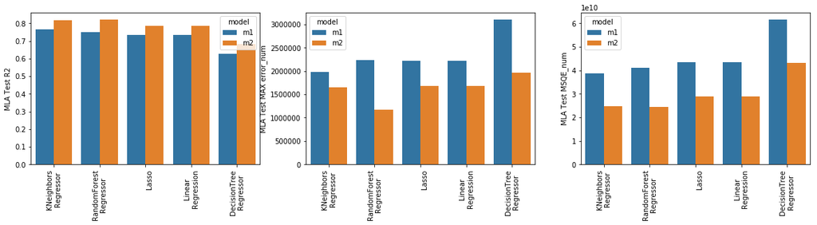

```python
# Make the long names of the models more presentable by splitting the string on the second capital letter
compare_all["MLA Name_present"] = [s[:[i for i, c in enumerate(s) \
                                   if c.isupper()][-1]]+"\n"+s[[i for i, c in enumerate(s) if \
                                                                                              c.isupper()][-1]:] for s in compare_all["MLA Name"]]

fig, ax = plt.subplots(nrows = 1, ncols = 3, figsize = (20, 4))
sns.barplot(x="MLA Name_present", y="MLA Test R2", hue="model", data=compare_all, ax= ax[0])
ax[0].set_xticklabels(ax[0].get_xticklabels(), rotation = 90)
ax[0].set_xlabel("")

compare_all["MLA Test MAX error_num"] = [abs(int("".join(x.split(",")))) for x in compare_all["MLA Test MAX error"]]
sns.barplot(x="MLA Name_present", y="MLA Test MAX error_num", hue="model", data=compare_all, ax= ax[1])
ax[1].set_xticklabels(ax[1].get_xticklabels(), rotation = 90)
ax[1].set_xlabel("")

compare_all["MLA Test MSQE_num"] = [abs(int("".join(x.split(",")))) for x in compare_all["MLA Test MSQE"]]
sns.barplot(x="MLA Name_present", y="MLA Test MSQE_num", hue="model", data=compare_all, ax= ax[2])
ax[2].set_xticklabels(ax[2].get_xticklabels(), rotation = 90)
ax[2].set_xlabel("")


plt.show()
```

### Comments

By moving from a 3 feature model to 8 feature model:  
1) R2 have increased from around 0.76 to 0.82  
2) Maximum error has decreased substantially from 2m to 1.2m 3) Mean squared error (MSQ) has also declined substantially 4) Top 2 models are Random Forest and KNN